# Project: Patient Appointment no show analysis

- Introduction
- Data Wrangling
- Exploratory Data Analysis
- Conclusions

## Introduction

In this report I would be looking at a data which reports patient who showed up for their scheduled appointment or not. The data set records the appointment date, scheduled date, gender, patient id, Age, neighbourhood.

The dependent variable, 'No-show' consist of 'yes' or 'No' values corresponding to when a scheduled appointment was missed or when a scheduled appointment was honored respectively.

My research questions are:

1. Are certain age groups more prone to missing their appointment than others?
2. Does gender influence appointments no shows?
3. What neighbourhoods has the highest paercentage of no shows?
4. On what day of the week are patients most likely to miss their appointment?

```python
# Use this cell to set up import statements for all of the packages that you
#   plan to use.
import re
import numpy as np
import pandas as pd
import matplotlib.pyplot as plt
import seaborn as sns

%matplotlib inline
pd.options.mode.chained_assignment = None
# Remember to include a 'magic word' so that your visualizations are plotted
#   inline with the notebook. See this page for more:
#   http://ipython.readthedocs.io/en/stable/interactive/magics.html
```

## Data Wrangling

### General Properties

```python
# Load your data and print out a few lines. Perform operations to inspect data
#   types and look for instances of missing or possibly errant data.
df= pd.read_csv('noshowappointments-kagglev2-may-2016.csv')
```

```python
# to have a look at the contents of the data
df.head()
```

|  | PatientId | AppointmentID | Gender | ScheduledDay | AppointmentDay | Age | Neighbourhood | Scholarship | Hipertension | Diabetes | Alcoholism | Handcap | SMS_received | No-show |
| --- | --- | --- | --- | --- | --- | --- | --- | --- | --- | --- | --- | --- | --- | --- |
| 0 | 2.987250e+13 | 5642903 | F | 2016-04-29T18:38:08Z | 2016-04-29T00:00:00Z | 62 | JARDIM DA PENHA | 0 | 1 | 0 | 0 | 0 | 0 | No |
| 1 | 5.589978e+14 | 5642503 | M | 2016-04-29T16:08:27Z | 2016-04-29T00:00:00Z | 56 | JARDIM DA PENHA | 0 | 0 | 0 | 0 | 0 | 0 | No |
| 2 | 4.262962e+12 | 5642549 | F | 2016-04-29T16:19:04Z | 2016-04-29T00:00:00Z | 62 | MATA DA PRAIA | 0 | 0 | 0 | 0 | 0 | 0 | No |
| 3 | 8.679512e+11 | 5642828 | F | 2016-04-29T17:29:31Z | 2016-04-29T00:00:00Z | 8 | PONTAL DE CAMBURI | 0 | 0 | 0 | 0 | 0 | 0 | No |
| 4 | 8.841186e+12 | 5642494 | F | 2016-04-29T16:07:23Z | 2016-04-29T00:00:00Z | 56 | JARDIM DA PENHA | 0 | 1 | 1 | 0 | 0 | 0 | No |

```python
# Checking for datatype of the various columns
df.info()
```

```
<class 'pandas.core.frame.DataFrame'>
RangeIndex: 110527 entries, 0 to 110526
Data columns (total 14 columns):
 #   Column          Non-Null Count   Dtype
---  ------          --------------   -----
 0   PatientId       110527 non-null  float64
 1   AppointmentID   110527 non-null  int64
 2   Gender          110527 non-null  object
 3   ScheduledDay    110527 non-null  object
 4   AppointmentDay  110527 non-null  object
 5   Age             110527 non-null  int64
 6   Neighbourhood   110527 non-null  object
 7   Scholarship     110527 non-null  int64
 8   Hipertension    110527 non-null  int64
 9   Diabetes        110527 non-null  int64
 10  Alcoholism      110527 non-null  int64
 11  Handcap         110527 non-null  int64
 12  SMS_received    110527 non-null  int64
 13  No-show         110527 non-null  object
dtypes: float64(1), int64(8), object(5)
memory usage: 11.8+ MB
```

```python
# Check for missing values in the data set
df.isna().sum()
```

```
PatientId         0
AppointmentID     0
Gender            0
ScheduledDay      0
AppointmentDay    0
Age               0
Neighbourhood     0
Scholarship       0
Hipertension      0
Diabetes          0
Alcoholism        0
Handcap           0
SMS_received      0
No-show           0
dtype: int64
```

```python
# Checkking for duplicated observations
df.duplicated().sum()
```

```
0
```

```python
# Checking summary statistics
df.describe()
```

|  | PatientId | AppointmentID | Age | Scholarship | Hipertension | Diabetes | Alcoholism | Handcap | SMS_received |
| --- | --- | --- | --- | --- | --- | --- | --- | --- | --- |
| count | 1.105270e+05 | 1.105270e+05 | 110527.000000 | 110527.000000 | 110527.000000 | 110527.000000 | 110527.000000 | 110527.000000 | 110527.000000 |
| mean | 1.474963e+14 | 5.675305e+06 | 37.088874 | 0.098266 | 0.197246 | 0.071865 | 0.030400 | 0.022248 | 0.321026 |
| std | 2.560949e+14 | 7.129575e+04 | 23.110205 | 0.297675 | 0.397921 | 0.258265 | 0.171686 | 0.161543 | 0.466873 |
| min | 3.921784e+04 | 5.030230e+06 | -1.000000 | 0.000000 | 0.000000 | 0.000000 | 0.000000 | 0.000000 | 0.000000 |
| 25% | 4.172614e+12 | 5.640286e+06 | 18.000000 | 0.000000 | 0.000000 | 0.000000 | 0.000000 | 0.000000 | 0.000000 |
| 50% | 3.173184e+13 | 5.680573e+06 | 37.000000 | 0.000000 | 0.000000 | 0.000000 | 0.000000 | 0.000000 | 0.000000 |
| 75% | 9.439172e+13 | 5.725524e+06 | 55.000000 | 0.000000 | 0.000000 | 0.000000 | 0.000000 | 0.000000 | 1.000000 |
| max | 9.999816e+14 | 5.790484e+06 | 115.000000 | 1.000000 | 1.000000 | 1.000000 | 1.000000 | 4.000000 | 1.000000 |

```python
# Checking for the unique values of each column
for i in df.columns:
    print(f'{i} contains "{df[i].nunique()}" unique values.\n')
```

```
PatientId contains "62299" unique values.

AppointmentID contains "110527" unique values.

Gender contains "2" unique values.

ScheduledDay contains "103549" unique values.

AppointmentDay contains "27" unique values.

Age contains "104" unique values.

Neighbourhood contains "81" unique values.

Scholarship contains "2" unique values.

Hipertension contains "2" unique values.

Diabetes contains "2" unique values.

Alcoholism contains "2" unique values.

Handcap contains "5" unique values.

SMS_received contains "2" unique values.

No-show contains "2" unique values.
```

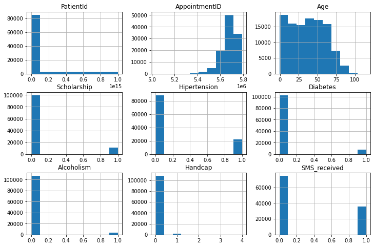

```python
df.hist(figsize=(12,8));
```

#### Observations

1. Data set contains 14 columns of 13 features of a candidate show or not to an appointment.
2. The dataset contains 110,527 observations with no duplicates although there is a repeat of patient id indicating a/some patient(s) must have been observed more than once.
3. The data consist of 5 non-numerical and 9 numerical columns.
4. Schedule day and and appointment time look to be datetime datatypes but wrongly classified
5. Handcap contains more unique values than expected. Column should have 'yes' and 'no' values only

### Data Cleaning

```python
# removing duplicate patient id, so all patient observations carry the same weight.
df_cleaned= df.drop_duplicates(subset='PatientId', keep='first')
```

```python
df_cleaned.info()
```

```
<class 'pandas.core.frame.DataFrame'>
Int64Index: 62299 entries, 0 to 110524
Data columns (total 14 columns):
 #   Column          Non-Null Count  Dtype
---  ------          --------------  -----
 0   PatientId       62299 non-null  float64
 1   AppointmentID   62299 non-null  int64
 2   Gender          62299 non-null  object
 3   ScheduledDay    62299 non-null  object
 4   AppointmentDay  62299 non-null  object
 5   Age             62299 non-null  int64
 6   Neighbourhood   62299 non-null  object
 7   Scholarship     62299 non-null  int64
 8   Hipertension    62299 non-null  int64
 9   Diabetes        62299 non-null  int64
 10  Alcoholism      62299 non-null  int64
 11  Handcap         62299 non-null  int64
 12  SMS_received    62299 non-null  int64
 13  No-show         62299 non-null  object
dtypes: float64(1), int64(8), object(5)
memory usage: 7.1+ MB
```

```python
# Converting the scheduledday and appointmentday columns into datetime formats
df_cleaned['ScheduledDay'] = df_cleaned['ScheduledDay'].astype('datetime64')
df_cleaned['AppointmentDay'] = df_cleaned['AppointmentDay'].astype('datetime64')
```

```python
df_cleaned.info()
```

```
<class 'pandas.core.frame.DataFrame'>
Int64Index: 62299 entries, 0 to 110524
Data columns (total 14 columns):
 #   Column          Non-Null Count  Dtype
---  ------          --------------  -----
 0   PatientId       62299 non-null  float64
 1   AppointmentID   62299 non-null  int64
 2   Gender          62299 non-null  object
 3   ScheduledDay    62299 non-null  datetime64[ns]
 4   AppointmentDay  62299 non-null  datetime64[ns]
 5   Age             62299 non-null  int64
 6   Neighbourhood   62299 non-null  object
 7   Scholarship     62299 non-null  int64
 8   Hipertension    62299 non-null  int64
 9   Diabetes        62299 non-null  int64
 10  Alcoholism      62299 non-null  int64
 11  Handcap         62299 non-null  int64
 12  SMS_received    62299 non-null  int64
 13  No-show         62299 non-null  object
dtypes: datetime64[ns](2), float64(1), int64(8), object(3)
memory usage: 7.1+ MB
```

```python
def add_datepart(df, fldname):
    """
    This function adds the year, month, week, and day of week to a dataframe.
    df= name of dataframe
    fldname
    """
    fld = df[fldname]
    targ_pre = re.sub('[Dd]ates','', fldname)
    for n in ("Year", "Month", "Dayofweek",):
        df[targ_pre+n] = getattr(fld.dt, n.lower())
    return df
```

#### Note

This function will enable the creation of a day of the week column to be used in answering Question 4

```python
df_cleaned= add_datepart(df_cleaned, 'AppointmentDay')
```

```python
df_cleaned.head()
```

|  | PatientId | AppointmentID | Gender | ScheduledDay | AppointmentDay | Age | Neighbourhood | Scholarship | Hipertension | Diabetes | Alcoholism | Handcap | SMS_received | No-show | AppointmentDayYear | AppointmentDayMonth | AppointmentDayDayofweek |
| --- | --- | --- | --- | --- | --- | --- | --- | --- | --- | --- | --- | --- | --- | --- | --- | --- | --- |
| 0 | 2.987250e+13 | 5642903 | F | 2016-04-29 18:38:08 | 2016-04-29 | 62 | JARDIM DA PENHA | 0 | 1 | 0 | 0 | 0 | 0 | No | 2016 | 4 | 4 |
| 1 | 5.589978e+14 | 5642503 | M | 2016-04-29 16:08:27 | 2016-04-29 | 56 | JARDIM DA PENHA | 0 | 0 | 0 | 0 | 0 | 0 | No | 2016 | 4 | 4 |
| 2 | 4.262962e+12 | 5642549 | F | 2016-04-29 16:19:04 | 2016-04-29 | 62 | MATA DA PRAIA | 0 | 0 | 0 | 0 | 0 | 0 | No | 2016 | 4 | 4 |
| 3 | 8.679512e+11 | 5642828 | F | 2016-04-29 17:29:31 | 2016-04-29 | 8 | PONTAL DE CAMBURI | 0 | 0 | 0 | 0 | 0 | 0 | No | 2016 | 4 | 4 |
| 4 | 8.841186e+12 | 5642494 | F | 2016-04-29 16:07:23 | 2016-04-29 | 56 | JARDIM DA PENHA | 0 | 1 | 1 | 0 | 0 | 0 | No | 2016 | 4 | 4 |

```python
# To create an extra column to categorise ages into age groups according to
#     Children, Youth, Adults and Seniors.

bins= [0, 15, 25, 65, 150]
bins2= [0,1,2,3,4,5,6]
labels= ['Children', 'Youth', 'Adults', 'Seniors']
labels2= ['Monday', 'Tuesday', 'Wednesday', 'Thursday', 'Friday', 'Saturday']
age_subdf= df_cleaned.copy()['Age']
age_subdf2= df_cleaned.copy()['AppointmentDayDayofweek']
df_cleaned['Age group']= pd.cut(age_subdf, bins=bins, labels=labels, right=False)
df_cleaned['Weekday']= pd.cut(age_subdf, bins=bins2, labels=labels2, right=False)
```

## Exploratory Data Analysis

```python
# Creating a function to allow creation of percentage grouping per feature against the dependent variable 'No-show'.
# This is because different amounts of observation per category per feature are sampled, thus a simple count of observation
#   will be misleading but a ratio of show to no-show for each category in a feature gives an objective comparission basis.
# rather that Percentage was used as it is a more visually pleasing metric than ratio.

def pct_group_df(df, groupby_col, agg_col):
    """
    This function returns a dataframe that have been grouped and aggregated by [ercentage a parameter existing in the dataframe
    df= dataframe to be used to create new subset of the dataframe
    groupby_col= column to group by
    agg_col= aggregate column
    """


    df1= df.groupby(groupby_col)[agg_col].value_counts(normalize=True).mul(100).rename('Percentage(%)')
    df2= pd.DataFrame(df1).reset_index()
    df2.rename({'level_1': agg_col}, axis=1, inplace=True)
    return df2
```

```python
# Creating a plot function to enable easy plotting

def plot_bar(df, y_axis, x_axis, z_axis=None, title='title', NoShow=None, plotsize=None, color=None):
    """
    This function returns a Bar plot of a dataframe
    df= dataframe to be used in plot
    y_axis= string of relevant column name to be used in as Y-axis of the plot
    x_axis= string of relevant column name to be used in as X-axis of the plot
    z_axis= string of relevant column name to be used as a third variable in the plot
    title= title to be used as the plot title
    NoShow= Default None. Yes subsets the
    """


    fig, axes= plt.subplots(figsize= plotsize)

    if NoShow== None:
        df_use= df
    else:
        df_use= df[df['No-show']== NoShow]

    sns.barplot(x= x_axis, y= y_axis, hue=z_axis, data= df_use, ci=False, color=color)
    plt.ylabel(y_axis)
    plt.title(title)

    return plt.tight_layout()
```

### Q1. Are certain age groups more prone to missing their appointment than others?

```python
age_noshow= pct_group_df(df_cleaned, 'Age group', 'No-show')
age_noshow.head(1)
```

|  | Age group | No-show | Percentage(%) |
| --- | --- | --- | --- |
| 0 | Children | No | 79.750645 |

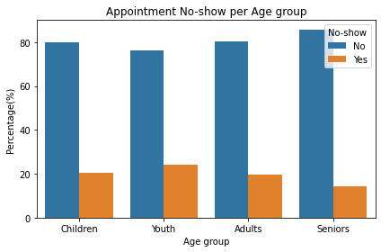

```python
# Creating a barplot of the number of observations of appointment no-shows per age group.

a = plot_bar(df=age_noshow, y_axis='Percentage(%)', x_axis='Age group', z_axis='No-show',
             title='Appointment No-show per Age group', NoShow=None)
```

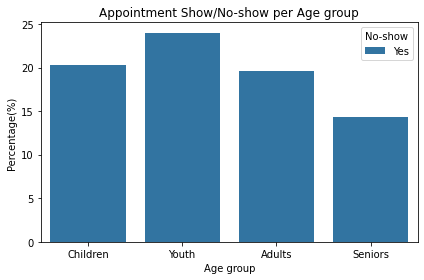

```python
# Creating a barplot showing the number of observations of appointment show/No-show per Age group
# No-show 'Yes' means that the patient did not show up to his scheduled appointment, while
#     'No' means the patient appeared
plot_bar(df=age_noshow, y_axis='Percentage(%)', x_axis='Age group',
         z_axis='No-show', title='Appointment Show/No-show per Age group', NoShow='Yes')
```

### Q2. Does gender influence appointments appointment no shows?

```python
# Creating a dataframe to group by percentage of Appointment No-show/show per gender.
# This paints a better picture as there were more females sampled in the data set.
# As such a Percentage of missed
gender_df= pct_group_df(df_cleaned, 'Gender', 'No-show')
```

```python
gender_df
```

|  | Gender | No-show | Percentage(%) |
| --- | --- | --- | --- |
| 0 | F | No | 80.452480 |
| 1 | F | Yes | 19.547520 |
| 2 | M | No | 80.384667 |
| 3 | M | Yes | 19.615333 |

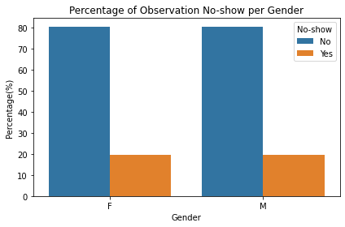

```python
# Creating a barplot of the vari
plot_bar(df= gender_df, z_axis='No-show', y_axis='Percentage(%)', x_axis='Gender',
         title='Percentage of Observation No-show per Gender', NoShow= None )
```

#### Observation

Appoximately thesame ratio of males and females miss their scheduled appointments, thus Gender does not affect appointment no-shows

### Q3. What neighbourhoods has the highest paercentage of no shows

```python
# to create a dataframe that compares percentage of appointment show/no-show per neighbourhood
# the new dataframe is then sorted in the second line of code in orger to show order in the plot
neighbourhood_df= pct_group_df(df_cleaned, 'Neighbourhood', 'No-show')
neighbourhood_df= neighbourhood_df.sort_values(by= ['Percentage(%)', 'No-show'], ascending=False)
```

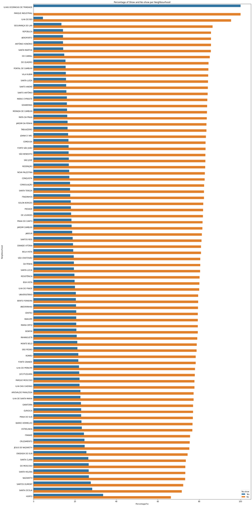

```python
plot_bar(x_axis='Percentage(%)', y_axis='Neighbourhood', z_axis='No-show', df= neighbourhood_df,
         title= 'Percentage of Show and No-show per Neighbourhood', plotsize=(20, 40), NoShow=None)
```

The above looks a whole lot to take in so let us hone in on the appointment no-show

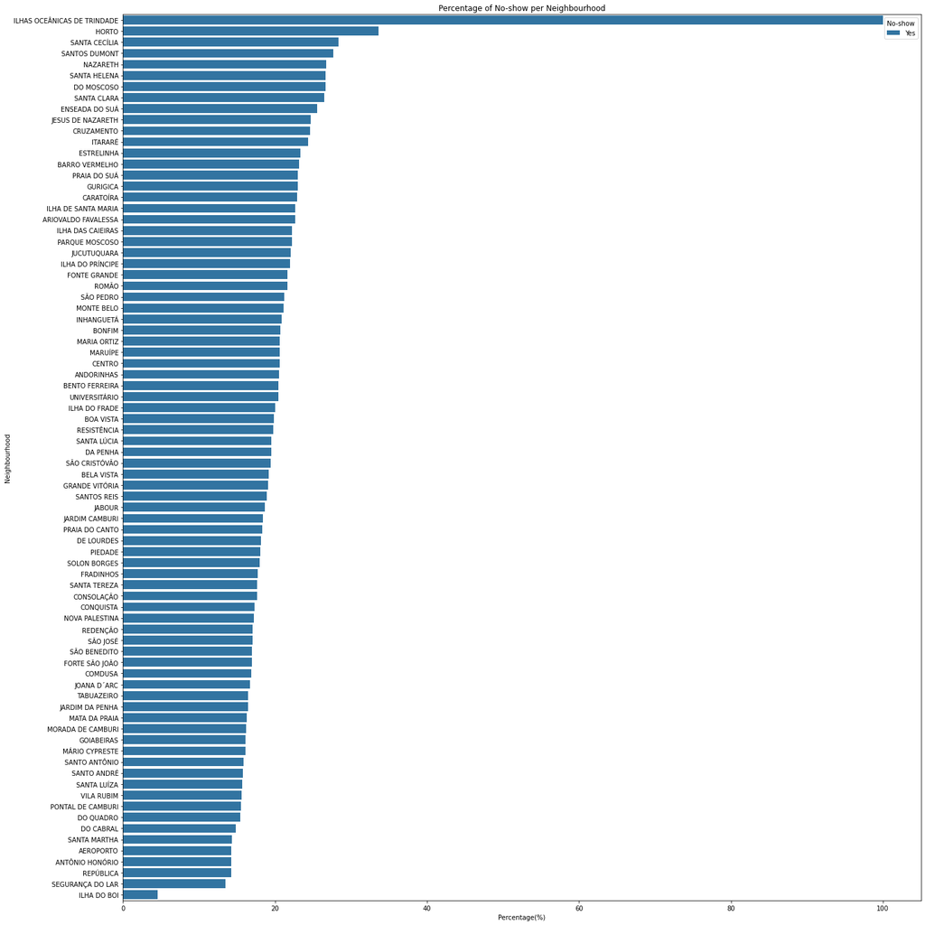

```python
# Creating a plot of no show per Neighbourhood

plot_bar(x_axis='Percentage(%)', y_axis='Neighbourhood', z_axis='No-show', df= neighbourhood_df,
         title= 'Percentage of No-show per Neighbourhood', plotsize=(20, 20), NoShow='Yes')
```

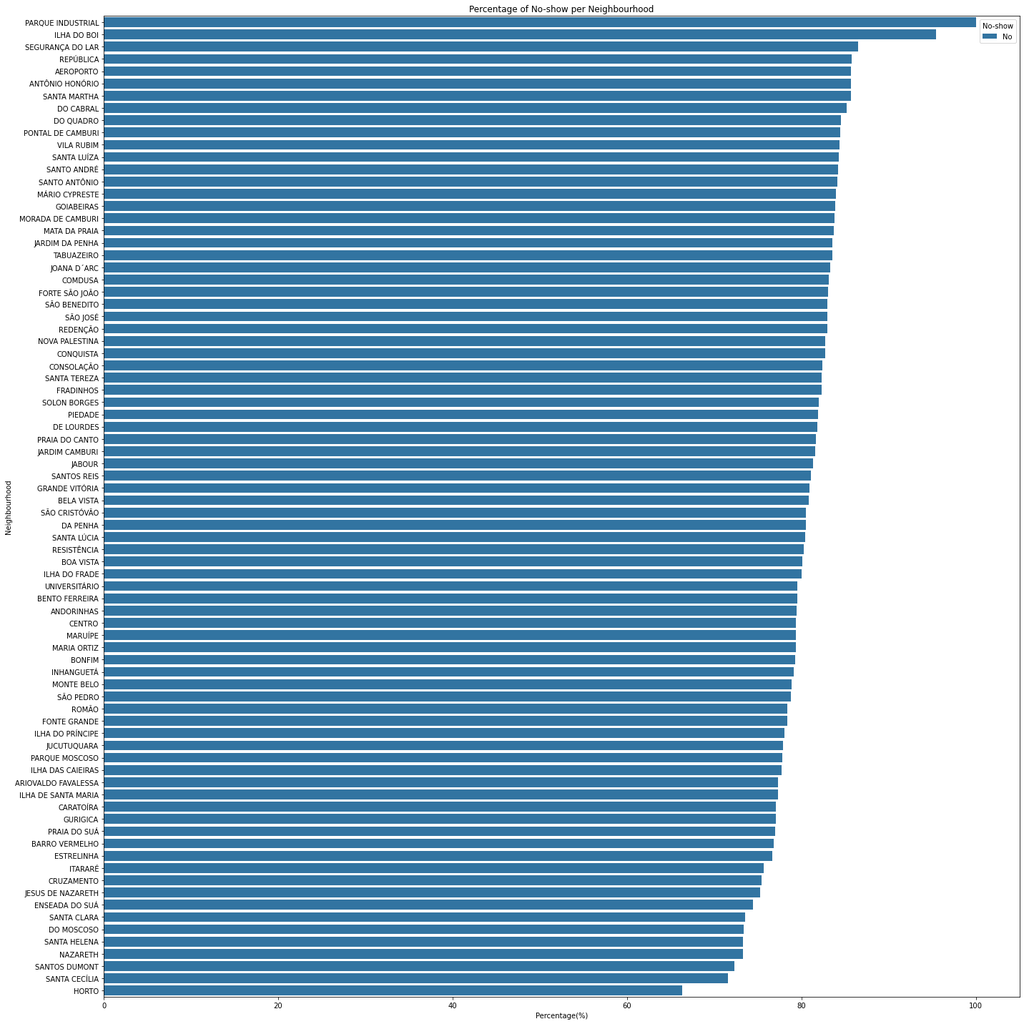

```python
# Creating a plot of appointment show ups per neighbouhood

# Showing the first five Neighbourhoods with highest appointment no-show

plot_bar(x_axis='Percentage(%)', y_axis='Neighbourhood', z_axis='No-show', df= neighbourhood_df,
         title= 'Percentage of No-show per Neighbourhood', plotsize=(20, 20), NoShow='No')
```

```python
# Showing the first five Neighbourhoods with highest appointment no-show

neighbourhood_df[neighbourhood_df['No-show']=='Yes'].sort_values(by=['Percentage(%)'], ascending=False).iloc[:5,:]
```

|  | Neighbourhood | No-show | Percentage(%) |
| --- | --- | --- | --- |
| 68 | ILHAS OCEÂNICAS DE TRINDADE | Yes | 100.000000 |
| 57 | HORTO | Yes | 33.663366 |
| 121 | SANTA CECÍLIA | Yes | 28.395062 |
| 139 | SANTOS DUMONT | Yes | 27.707454 |
| 98 | NAZARETH | Yes | 26.744186 |

```python
# Showing the first five Neighbourhoods with highest appointment show up.

neighbourhood_df[neighbourhood_df['No-show']=='No'].sort_values(by=['Percentage(%)'], ascending=False).iloc[:5,:]
```

|  | Neighbourhood | No-show | Percentage(%) |
| --- | --- | --- | --- |
| 101 | PARQUE INDUSTRIAL | No | 100.000000 |
| 62 | ILHA DO BOI | No | 95.454545 |
| 142 | SEGURANÇA DO LAR | No | 86.516854 |
| 114 | REPÚBLICA | No | 85.745140 |
| 0 | AEROPORTO | No | 85.714286 |

#### Observation

Neighbourhoods with the highest amount of appointment no-shows are shown above with Ihas Oceanicas de Trindade not recording any patient from the neighbouhood showing up for an appointment, while Parque Industrial has the best record of appointment show up, with all patients showing up.

### Q4. What day of the week is a client like to miss a scheduled appointment?

```python
# To create a dataset grouped by percentage of appointment show/no-show per day of week
day_df= pct_group_df(df_cleaned, 'Weekday',  'No-show')
```

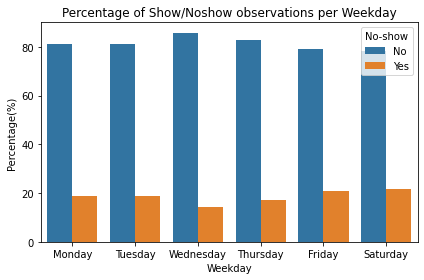

```python
plot_bar(x_axis='Weekday', y_axis='Percentage(%)', z_axis='No-show', df= day_df,
         title= 'Percentage of Show/Noshow observations per Weekday', plotsize=None, NoShow=None)
```

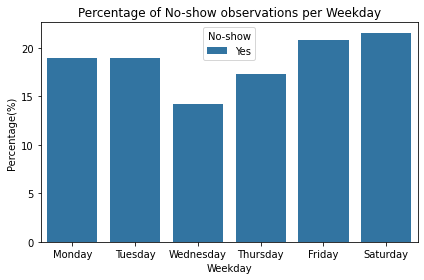

```python
plot_bar(x_axis='Weekday', y_axis='Percentage(%)', z_axis='No-show', df= day_df,
         title= 'Percentage of No-show observations per Weekday', plotsize=None, NoShow='Yes')
```

## Conclusions

#### Observations;

> Neighbourhood: Neighbourhoods with the highest amount of appointment no-shows are shown above with Ihas Oceanicas de Trindade not recording any patient from the neighbouhood showing up for an appointment, while Parque Industrial has the best record of appointment show up, with all patients showing up.

> Gender: Appoximately thesame ratio of males and females miss their scheduled appointments, thus Gender does not affect appointment no-shows

#### Constriants:

1. The predictor features are geared towards the adult to elderly and does no necessarily accomodate an inclusive population across all age groups. Therefore information on walkin cases would have provided a much fairer basis to compare the population.
1. The distance of the neghbourhoods from the hospital would have given better insights as to determing the kind of relationship between the dependent variable and neighbourhood.